# Least Squares

Suppose we would like to solve the system $A \mathbf x = \mathbf b$ but we find that it is inconsistent. In other words, $\mathbf b \notin C(A)$, perhaps because there are too many equations or $C(A)$ is too small. The next best thing, then, would be to solve $A \mathbf{\hat x} = \mathbf{\hat b}$, where $\mathbf{\hat b}$ is the orthogonal projection of $\mathbf b$ onto $C(A)$. But we've already solved this problem and seen how to find $\mathbf{\hat x}$, the *least squares approximation* to the original system. We simply use the normal equations and solve

$$A^\top A \mathbf{\hat x} = A^\top \mathbf b.$$

The solution to the above is called the least-squares approximation of $\mathbf x$, because $\mathbf{\hat x}$ minimizes the (squared) norm of the error or *residual* vector $\mathbf e = \mathbf b - \mathbf{\hat b}$. In other words, this solution ensures that

$$||\mathbf e||^2 = ||\mathbf b - A \mathbf{\hat x}||^2 $$

is as small as possible. If an exact solution to the original system exists, then we would have $A \mathbf{\hat x} = \mathbf b$ and $\mathbf e = \mathbf 0$.

# Model Fitting

A common application of least squares apprximations is model fitting. A *model* consists of a function or set of functions that describes certain observations or outputs given a set of descriptors, features, or inputs. Models are important for helping us to summarize, simplify, and overall have a better understanding of complicated and noisy real-world phenomena.

A *linear model* $f$ says that an output variable $y$ can be written as a linear combination of $n$ *features* $x_i$, weighted by a set of model *parameters* $\beta_i$. There may also be a constant offset $\beta_0$. Denoting $\mathbf x$ as the vector of all of these features, we can write this model in the form

$$y = f(\mathbf x) = \beta_0 + \beta_1 x_1 + \beta_2 x_2 + \cdots + \beta_n x_n$$

Now suppose that we are trying to find the best values for the model parameters $\beta_i$. Typically we would be working with a set of data, which contain $m$ sets of feature values $\mathbf x^{(i)}$ along with their outputs $y^{(i)}$. Using data to find the best-fitting model is the **linear regression** problem. Assuming that each $(\mathbf x^{(i)}, y^{(i)})$ pair follows the model, we can set up a system of linear equations $X \mathbf \beta = \mathbf y$:

$$\begin{bmatrix} 1 & x_1^{(1)} & x_2^{(1)} & \cdots & x_n^{(1)} \\ 1 & x_1^{(2)} & x_2^{(2)} & \cdots & x_n^{(2)} \\ \vdots & \vdots & \vdots & \ddots & \vdots \\ 1 & x_1^{(m)} & x_2^{(m)} & \cdots & x_n^{(m)} \end{bmatrix} \begin{bmatrix} \beta_0 \\ \beta_1 \\ \beta_2 \\ \vdots \\ \beta_n \end{bmatrix} = \begin{bmatrix} y^{(1)} \\ y^{(2)} \\ \vdots \\ y^{(m)}\end{bmatrix}$$

Note the structure of the matrix $X$: the first column consists entirely of 1 (for the constant parameter $\beta_0$), each row consists of a feature datum $\mathbf x^{(i)}$, and each column consists of the data for a specific feature $\mathbf x_j$. In the statistics treatment of this problem, $X$ is called the *design matrix*, $\mathbf \beta$ are the *regression coefficients*, and $\mathbf y$ is the *observation vector*.

Ideally, we can then solve for the parameters $\mathbf \beta$ such that all equations hold. But the model may not be entirely correct, or the data may be noisy and corrupted. So the best we can do is find the least-squares approximation $\mathbf{\hat \beta}$, which will then be the parameters to the best fitting model $\hat f$. This comes from solving the normal equations

$$X^\top X \mathbf{\hat \beta} = X^\top \mathbf y.$$

# Least Squares in NumPy

The `numpy.liangl.lstsq` function solves the linear regression problem given a design matrix $X$ and observation vector $\mathbf y$. It returns several quantities; the first is an array of estimated parameters $\mathbf{\hat \beta}$, and the second is the sum of squared residuals, or the squared norm of the error vector: $||\mathbf e||^2$. This second quantity is important for helping to assess the "goodness" of the fit. Even though we can always solve the regression problem, we also care about how useful our model is for actually describing the data.

In the example below, we generate 100 $(x,y)$ random pairs of "training data" (the function that we use to generate them is clearly nonlinear). We then try to fit them to a linear model $y = \beta_0 + \beta_1 x$. Of course, this is just a line, and the parameters form the y-intercept and slope. After solving for the parameters we can plot the line on the data to visualize the fit.

$$\begin{bmatrix} 1 & x^{(1)} \\ 1 & x^{(2)} \\ \vdots & \vdots \\ 1 & x^{(m)} \end{bmatrix} \begin{bmatrix} \beta_0 \\ \beta_1 \end{bmatrix} = \begin{bmatrix} y^{(1)} \\ y^{(2)} \\ \vdots \\ y^{(m)}\end{bmatrix}$$

```
beta = [ 0.11647078 -0.36887914]
SSE = [5.14872297]
```

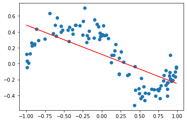

```python
import numpy as np
import matplotlib.pyplot as plt

# Generate 100 training data in the interval [-1,1]
m = 100
x = 2*np.random.rand(m) - 1
x = np.sort(x,axis=0)
y = x**3 - x + 0.4/(1+25*x**2) + 0.1*np.random.randn(m)

# Simple linear fit
X = np.column_stack((np.ones(m), x))
sol = np.linalg.lstsq(X, y, rcond=None)
beta = sol[0]
SSE = sol[1]

plt.scatter(x,y)
plt.plot(x, X @ beta, 'r')
print("beta =", beta)
print("SSE =", SSE)
```

# Nonlinear Models

Amazingly, linear regression can also be used to fit data to nonlinear models, as long as the parameters are still acting as scalar weights of different features. In general we may have a model of the form

$$f(\mathbf x) = \beta_0 + \beta_1 f_1(\mathbf x) + \beta_2 f_2(\mathbf x) + \cdots + \beta_n f_n(\mathbf x).$$

While the $f_i$ can now be any kind of function, the important part is that each of them can be extracted or computed from our given data. We then end up solving for the parameters $\mathbf \beta$ using least squares approximations as before.

For example, we can fit data to a parabola according to the model $f(x) = \beta_0 + \beta_1 x + \beta_2 x^2$. The system $X \beta = \mathbf y$ would look like

$$\begin{bmatrix} 1 & x^{(1)} & (x^{(1)})^2 \\ 1 & x^{(2)} & (x^{(2)})^2 \\ \vdots & \vdots & \vdots \\ 1 & x^{(m)} & (x^{(m)})^2 \end{bmatrix} \begin{bmatrix} \beta_0 \\ \beta_1 \\ \beta_2 \end{bmatrix} = \begin{bmatrix} y^{(1)} \\ y^{(2)} \\ \vdots \\ y^{(m)}\end{bmatrix}.$$

Alternatively, if we suspect our data to follow some kind of periodic model, we may want to try something like $f(x) = \beta_0 + \beta_1 \cos(x) + \beta_2 \sin(x)$. We would then set up the system

$$\begin{bmatrix} 1 & \cos x^{(1)} & \sin x^{(1)} \\ 1 & \cos x^{(2)} & \sin x^{(2)} \\ \vdots & \vdots & \vdots \\ 1 & \cos x^{(m)} & \sin x^{(m)} \end{bmatrix} \begin{bmatrix} \beta_0 \\ \beta_1 \\ \beta_2 \end{bmatrix} = \begin{bmatrix} y^{(1)} \\ y^{(2)} \\ \vdots \\ y^{(m)}\end{bmatrix}.$$

```
beta = [ 0.23424057 -0.34912728 -0.3060775 ]
SSE = [4.07331775]
```

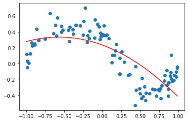

```python
# Quadratic fit: y(x) = beta0 + beta1*x + beta2*x^2
X = np.column_stack((np.ones(m), x, np.power(x,2)))
sol = np.linalg.lstsq(X, y, rcond=None)
beta = sol[0]
SSE = sol[1]

plt.scatter(x,y)
plt.plot(x, X @ beta, 'r')
print("beta =", beta)
print("SSE =", SSE)
```

```
beta = [ 0.34693178 -0.9333685  -2.02797033  0.60004755  3.95186728  0.30595817
 -2.33567522]
SSE = [0.95435231]
```

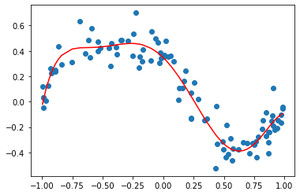

```python
# Polynomial of degree 6: y(x) = beta0 + beta1*x + beta2*x^2 + beta3*x^3
#                                + beta4*x^4 + beta5*x^5 + beta6*x^6
X = np.column_stack((np.ones(m), x, np.power(x,2), np.power(x,3),
                     np.power(x,4), np.power(x,5), np.power(x,6)))
sol = np.linalg.lstsq(X, y, rcond=None)
beta = sol[0]
SSE = sol[1]

plt.scatter(x,y)
plt.plot(x, X @ beta, 'r')
print("beta =", beta)
print("SSE =", SSE)
```

Comparing the SSE of each of three models that we tried fitting above, we should see that the last one (polynomial of degree 6) has the lowest error. This suggests that this model is closest to the "true" model that generated the data.